# R Notebook

# Libraries

```r
library(tidyverse)
library(janitor)
library(GGally)
library(ggfortify)
library(modelr)
library(caret)
```

# Data

```r
red_wine <- read_csv("data/wine_quality_red.csv")
white_wine <- read_csv("data/wine_quality_white.csv")
```

# Exploration

## Red Wine

```r
#glimpse(red_wine)
```

Thoughts and findings:

- wine_id is not needed
- what is the difference between the acidities? Are these related to citric acid conc? Maybe only one is needed?
- is there an interaction with sulfur dioxides? Perhaps a ratio of free:total would be interesting
- Density is related to sugar and alcohol according to the dictionary

```r
red_wine <- red_wine %>%
  select(-wine_id) %>%
  mutate(prop_sulfur_dioxide = free_sulfur_dioxide / total_sulfur_dioxide,
         acidity_ratio = citric_acid / volatile_acidity)
```

```r
skimr::skim(red_wine) %>%  View()
```

Could be transformed: residual_sugar, chloride, sulfur_dioxide, sulfates, alcohol?

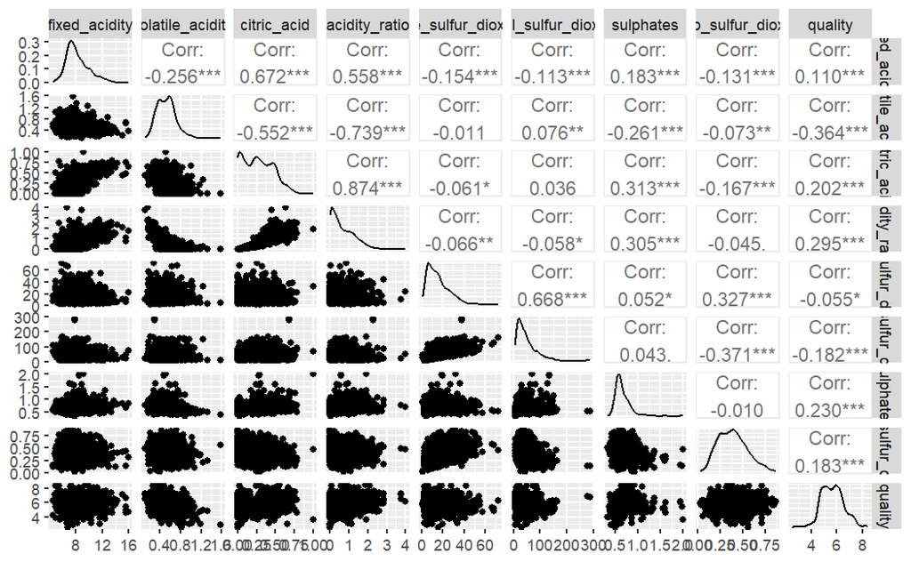

```r
red_wine %>%
  select(1:3, acidity_ratio, 6:7, sulphates, prop_sulfur_dioxide, quality) %>%
  ggpairs()
```

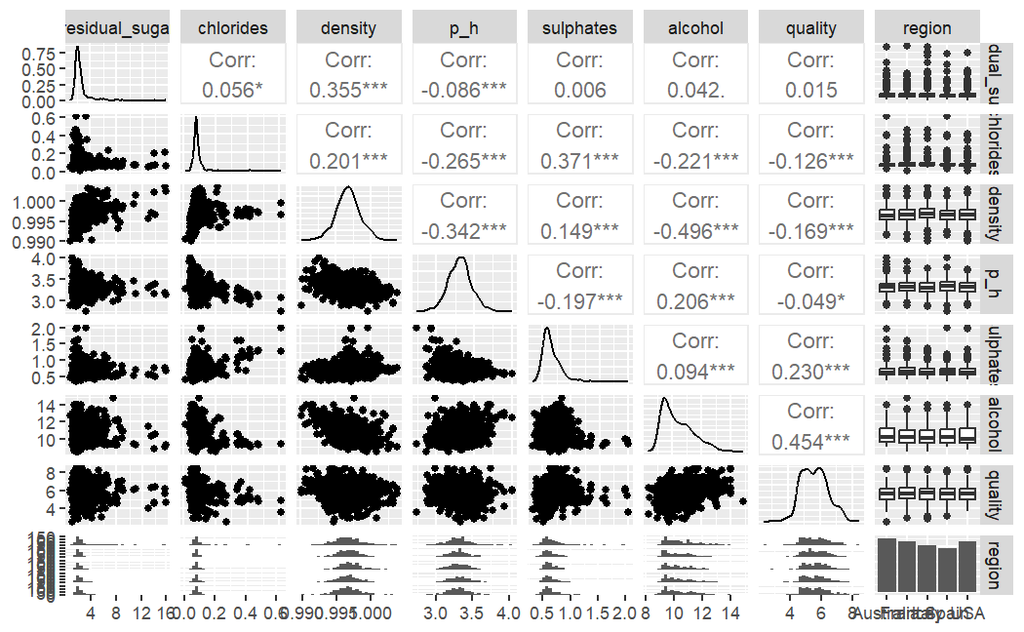

```r
red_wine %>%
  select(4:5, 8:13) %>%
  ggpairs()
```

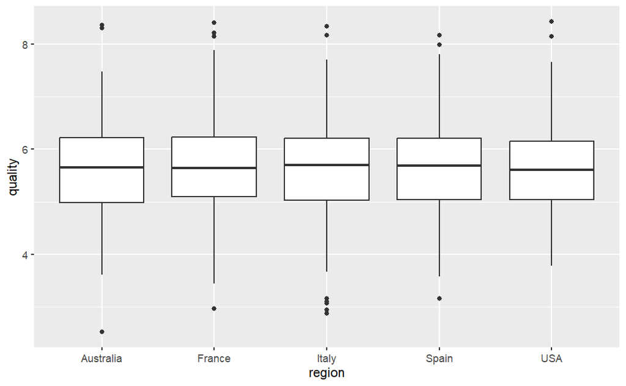

```r
red_wine %>%
  ggplot(aes(region, quality)) +
  geom_boxplot()
```

- alcohol 0.454
- volatile_acidity -0.364
- acidity_ratio 0.295
- sulfates 0.230
- prop_sulfur 0.183
- density -0.169

## White Wine

```r
skimr::skim(white_wine) %>%  View()
```

```r
white_wine <- white_wine %>%
  select(-wine_id) %>%
  mutate(prop_sulfur_dioxide = free_sulfur_dioxide / total_sulfur_dioxide,
         acidity_ratio = citric_acid / volatile_acidity)
```

Test train split (for red wine I will try k-fold validation and here train test split to compare and try both methods) (should have done first!)

```r
n_data <- nrow(white_wine)
test_prop <- 0.2
test_index <- sample(1:n_data, n_data * test_prop)

test <- slice(white_wine, test_index)
train <- slice(white_wine, -test_index)
```

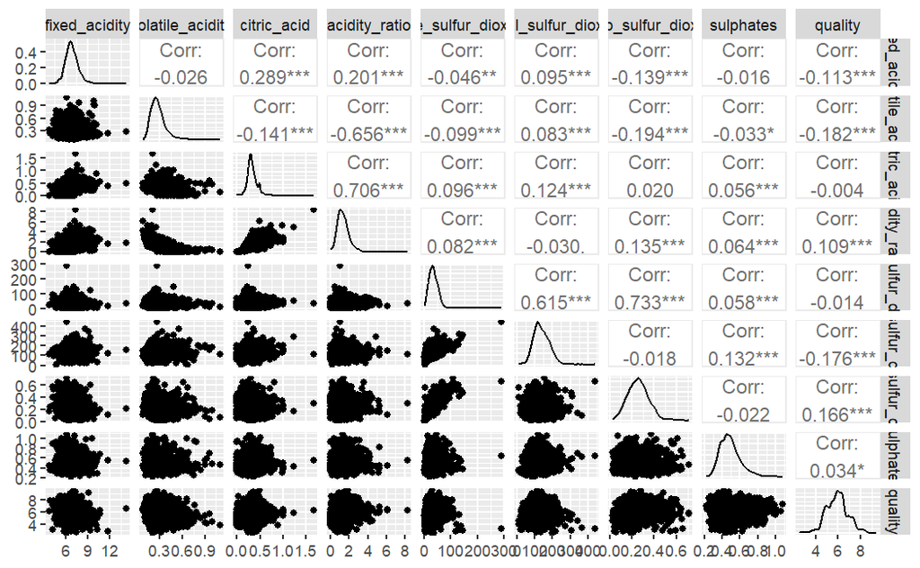

```r
train %>%
  select(1:3, acidity_ratio, 6:7, prop_sulfur_dioxide, sulphates, quality) %>%
  ggpairs()
```

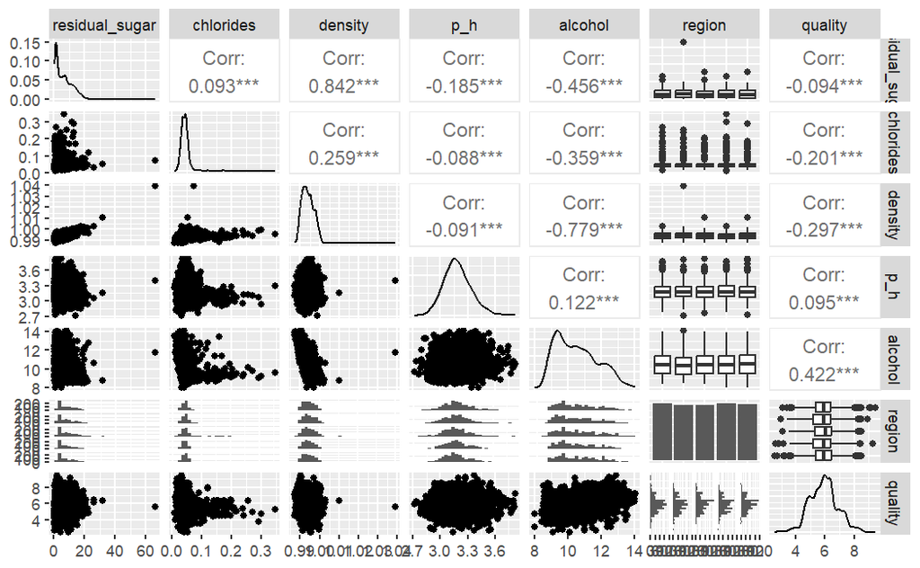

```r
train %>%
  select(4:5, 8:9, alcohol, region, quality) %>%
  ggpairs()
```

## Conclusions

Red: * alcohol 0.454 * volatile_acidity -0.364 * acidity_ratio 0.295 * sulfates 0.230 * prop_sulfur 0.183 * density -0.169

Red and white wine quality have different correlations with predictors, that is, different things make red or white wine “good”.  
Two separate models would therefore be better than trying to combine them into a single model.

# Red model

## Round 1

```r
mod_red1a <- lm(quality ~ alcohol, red_wine)
mod_red1b <- lm(quality ~ volatile_acidity, red_wine)

summary(mod_red1a)
```

```
Call:
lm(formula = quality ~ alcohol, data = red_wine)

Residuals:
     Min       1Q   Median       3Q      Max
-2.95517 -0.50166 -0.04501  0.49519  2.70011

Coefficients:
            Estimate Std. Error t value Pr(>|t|)
(Intercept)  1.89570    0.18603   10.19   <2e-16 ***
alcohol      0.36142    0.01776   20.36   <2e-16 ***
---
Signif. codes:  0 ‘***’ 0.001 ‘**’ 0.01 ‘*’ 0.05 ‘.’ 0.1 ‘ ’ 1

Residual standard error: 0.7564 on 1597 degrees of freedom
Multiple R-squared:  0.206, Adjusted R-squared:  0.2055
F-statistic: 414.4 on 1 and 1597 DF,  p-value: < 2.2e-16
```

```r
summary(mod_red1b)
```

```
Call:
lm(formula = quality ~ volatile_acidity, data = red_wine)

Residuals:
     Min       1Q   Median       3Q      Max
-2.74440 -0.54813 -0.02734  0.53280  2.77353

Coefficients:
                 Estimate Std. Error t value Pr(>|t|)
(Intercept)       6.57413    0.06155  106.81   <2e-16 ***
volatile_acidity -1.72666    0.11044  -15.63   <2e-16 ***
---
Signif. codes:  0 ‘***’ 0.001 ‘**’ 0.01 ‘*’ 0.05 ‘.’ 0.1 ‘ ’ 1

Residual standard error: 0.7905 on 1597 degrees of freedom
Multiple R-squared:  0.1327,    Adjusted R-squared:  0.1322
F-statistic: 244.4 on 1 and 1597 DF,  p-value: < 2.2e-16
```

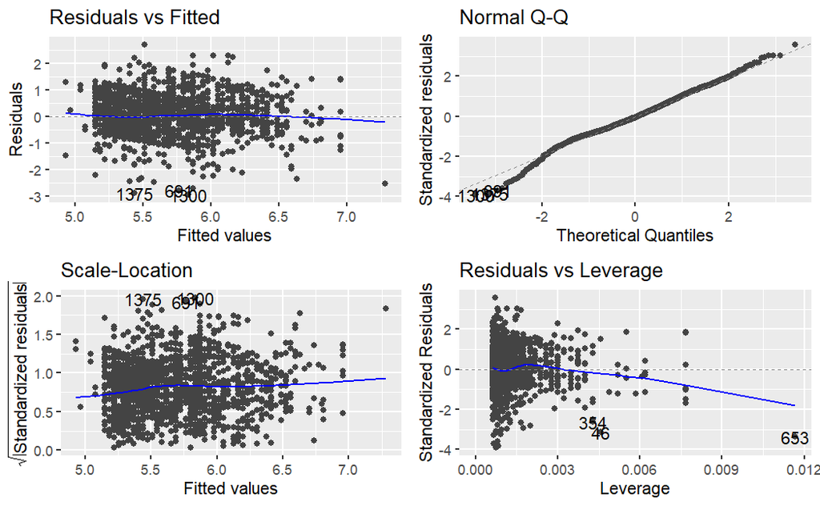

```r
autoplot(mod_red1a)
```

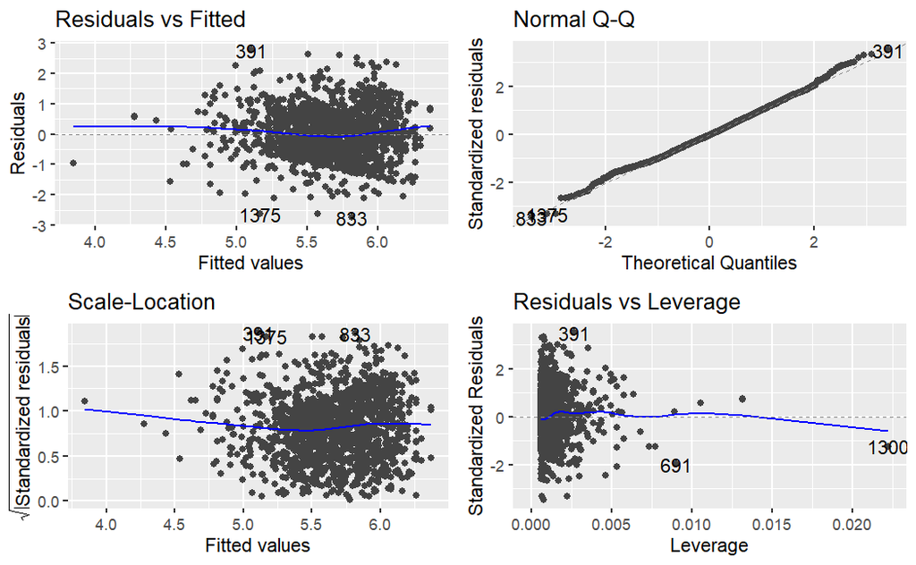

```r
autoplot(mod_red1b)
```

Diagnostics are ok. There is perhaps a slight pattern to mod_red1a in residuals vs fitted.

mod_red1a has the better r-squared, as expected due to the high correlation. **alcohol is first predictor**

## Round 2

```r
red_wine_resids <- red_wine %>%
  add_residuals(mod_red1a) %>%
  select(-quality, -alcohol)

ggpairs(red_wine_resids, columns = c(1:7, 14))
ggpairs(red_wine_resids, columns = c(8:14))
```

[output not shown]

- volatile_acidity
- acidity_ratio
- sulphates

```r
mod_red2a <- lm(quality ~ alcohol + volatile_acidity, red_wine)
mod_red2b <- lm(quality ~ alcohol + acidity_ratio, red_wine)
mod_red2c <- lm(quality ~ alcohol + sulphates, red_wine)


summary(mod_red2a)
summary(mod_red2b)
summary(mod_red2c)
```

[output not shown]

```r
autoplot(mod_red2a)
autoplot(mod_red2b)
autoplot(mod_red2c)
```

[output not shown]

mod_red2a has the best increase in adjusted r-squared as well as the best diagnostics. **volatile_acidity is best second predictor**

## Round 3

```r
red_wine_resids <- red_wine %>%
  add_residuals(mod_red2a) %>%
  select(-quality, -alcohol, -volatile_acidity)

ggpairs(red_wine_resids, columns = c(1:6, 13))
ggpairs(red_wine_resids, columns = c(7:13))
```

[output not shown]

- sulphates 0.140
- total_sulfur -0.093
- pH / prop -0.076

```r
mod_red3a <- lm(quality ~ alcohol + volatile_acidity + sulphates, red_wine)
mod_red3b <- lm(quality ~ alcohol + volatile_acidity + total_sulfur_dioxide, red_wine)
mod_red3c <- lm(quality ~ alcohol + volatile_acidity + p_h, red_wine)
mod_red3d <- lm(quality ~ alcohol + volatile_acidity + prop_sulfur_dioxide, red_wine)

summary(mod_red3a)
```

```
Call:
lm(formula = quality ~ alcohol + volatile_acidity + sulphates,
    data = red_wine)

Residuals:
     Min       1Q   Median       3Q      Max
-2.66345 -0.45393 -0.01326  0.48807  2.16111

Coefficients:
                 Estimate Std. Error t value Pr(>|t|)
(Intercept)       2.62881    0.21133  12.439  < 2e-16 ***
alcohol           0.31134    0.01707  18.241  < 2e-16 ***
volatile_acidity -1.19442    0.10476 -11.401  < 2e-16 ***
sulphates         0.63716    0.10886   5.853 5.84e-09 ***
---
Signif. codes:  0 ‘***’ 0.001 ‘**’ 0.01 ‘*’ 0.05 ‘.’ 0.1 ‘ ’ 1

Residual standard error: 0.7114 on 1595 degrees of freedom
Multiple R-squared:  0.2985,    Adjusted R-squared:  0.2972
F-statistic: 226.2 on 3 and 1595 DF,  p-value: < 2.2e-16
```

```r
summary(mod_red3b)
```

```
Call:
lm(formula = quality ~ alcohol + volatile_acidity + total_sulfur_dioxide,
    data = red_wine)

Residuals:
     Min       1Q   Median       3Q      Max
-2.59857 -0.46567 -0.00493  0.47816  2.34073

Coefficients:
                       Estimate Std. Error t value Pr(>|t|)
(Intercept)           3.3098333  0.2064688  16.031  < 2e-16 ***
alcohol               0.3026720  0.0174912  17.304  < 2e-16 ***
volatile_acidity     -1.3324944  0.1021723 -13.042  < 2e-16 ***
total_sulfur_dioxide -0.0021197  0.0005566  -3.809 0.000145 ***
---
Signif. codes:  0 ‘***’ 0.001 ‘**’ 0.01 ‘*’ 0.05 ‘.’ 0.1 ‘ ’ 1

Residual standard error: 0.7157 on 1595 degrees of freedom
Multiple R-squared:  0.2899,    Adjusted R-squared:  0.2886
F-statistic: 217.1 on 3 and 1595 DF,  p-value: < 2.2e-16
```

```r
summary(mod_red3c)
```

```
Call:
lm(formula = quality ~ alcohol + volatile_acidity + p_h, data = red_wine)

Residuals:
     Min       1Q   Median       3Q      Max
-2.73715 -0.46930 -0.01991  0.48009  2.40802

Coefficients:
                 Estimate Std. Error t value Pr(>|t|)
(Intercept)       4.20209    0.39749  10.572   <2e-16 ***
alcohol           0.33103    0.01782  18.577   <2e-16 ***
volatile_acidity -1.24668    0.10677 -11.676   <2e-16 ***
p_h              -0.40215    0.12392  -3.245   0.0012 **
---
Signif. codes:  0 ‘***’ 0.001 ‘**’ 0.01 ‘*’ 0.05 ‘.’ 0.1 ‘ ’ 1

Residual standard error: 0.7166 on 1595 degrees of freedom
Multiple R-squared:  0.2881,    Adjusted R-squared:  0.2868
F-statistic: 215.2 on 3 and 1595 DF,  p-value: < 2.2e-16
```

```r
summary(mod_red3d)
```

```
Call:
lm(formula = quality ~ alcohol + volatile_acidity + prop_sulfur_dioxide,
    data = red_wine)

Residuals:
     Min       1Q   Median       3Q      Max
-2.67455 -0.46849 -0.01916  0.48159  2.46720

Coefficients:
                    Estimate Std. Error t value Pr(>|t|)
(Intercept)          3.07322    0.19805   15.52  < 2e-16 ***
alcohol              0.30248    0.01769   17.10  < 2e-16 ***
volatile_acidity    -1.33894    0.10228  -13.09  < 2e-16 ***
prop_sulfur_dioxide  0.37540    0.11955    3.14  0.00172 **
---
Signif. codes:  0 ‘***’ 0.001 ‘**’ 0.01 ‘*’ 0.05 ‘.’ 0.1 ‘ ’ 1

Residual standard error: 0.7168 on 1595 degrees of freedom
Multiple R-squared:  0.2879,    Adjusted R-squared:  0.2865
F-statistic: 214.9 on 3 and 1595 DF,  p-value: < 2.2e-16
```

```r
autoplot(mod_red3a)
autoplot(mod_red3b)
autoplot(mod_red3c)
autoplot(mod_red3d)
```

[output not shown]

```r
anova(mod_red2a, mod_red3a)
```

[output not shown]

### Quality of model

*(You can’t use autoplot on K-fold models. Should you be using this method from the start anyway and look at diagnostics a different way, or can it be used as a check at the end?)*

```r
cv_10_fold <- trainControl(
  method = "cv",
  number = 10,
  savePredictions = TRUE
)
```

```r
mod_red1 <- train(quality ~ alcohol,
               data = red_wine,
               trControl = cv_10_fold,
               method = "lm")

mod_red2 <- train(quality ~ alcohol + volatile_acidity,
               data = red_wine,
               trControl = cv_10_fold,
               method = "lm")

mod_red3 <- train(quality ~ alcohol + volatile_acidity + sulphates,
               data = red_wine,
               trControl = cv_10_fold,
               method = "lm")

summary(mod_red1)
```

```
Call:
lm(formula = .outcome ~ ., data = dat)

Residuals:
     Min       1Q   Median       3Q      Max
-2.95517 -0.50166 -0.04501  0.49519  2.70011

Coefficients:
            Estimate Std. Error t value Pr(>|t|)
(Intercept)  1.89570    0.18603   10.19   <2e-16 ***
alcohol      0.36142    0.01776   20.36   <2e-16 ***
---
Signif. codes:  0 ‘***’ 0.001 ‘**’ 0.01 ‘*’ 0.05 ‘.’ 0.1 ‘ ’ 1

Residual standard error: 0.7564 on 1597 degrees of freedom
Multiple R-squared:  0.206, Adjusted R-squared:  0.2055
F-statistic: 414.4 on 1 and 1597 DF,  p-value: < 2.2e-16
```

```r
summary(mod_red2)
```

```
Call:
lm(formula = .outcome ~ ., data = dat)

Residuals:
     Min       1Q   Median       3Q      Max
-2.55192 -0.47030 -0.01778  0.47927  2.41435

Coefficients:
                 Estimate Std. Error t value Pr(>|t|)
(Intercept)       3.08357    0.19857   15.53   <2e-16 ***
alcohol           0.31565    0.01723   18.32   <2e-16 ***
volatile_acidity -1.34665    0.10254  -13.13   <2e-16 ***
---
Signif. codes:  0 ‘***’ 0.001 ‘**’ 0.01 ‘*’ 0.05 ‘.’ 0.1 ‘ ’ 1

Residual standard error: 0.7188 on 1596 degrees of freedom
Multiple R-squared:  0.2834,    Adjusted R-squared:  0.2825
F-statistic: 315.7 on 2 and 1596 DF,  p-value: < 2.2e-16
```

```r
summary(mod_red3)
```

```
Call:
lm(formula = .outcome ~ ., data = dat)

Residuals:
     Min       1Q   Median       3Q      Max
-2.66345 -0.45393 -0.01326  0.48807  2.16111

Coefficients:
                 Estimate Std. Error t value Pr(>|t|)
(Intercept)       2.62881    0.21133  12.439  < 2e-16 ***
alcohol           0.31134    0.01707  18.241  < 2e-16 ***
volatile_acidity -1.19442    0.10476 -11.401  < 2e-16 ***
sulphates         0.63716    0.10886   5.853 5.84e-09 ***
---
Signif. codes:  0 ‘***’ 0.001 ‘**’ 0.01 ‘*’ 0.05 ‘.’ 0.1 ‘ ’ 1

Residual standard error: 0.7114 on 1595 degrees of freedom
Multiple R-squared:  0.2985,    Adjusted R-squared:  0.2972
F-statistic: 226.2 on 3 and 1595 DF,  p-value: < 2.2e-16
```

```r
mean(mod_red1$resample$RMSE)
```

```
[1] 0.7554179
```

```r
mean(mod_red2$resample$RMSE)
```

```
[1] 0.718382
```

```r
mean(mod_red3$resample$RMSE)
```

```
[1] 0.7103795
```

```r
BIC(mod_red1a)
```

```
[1] 3664.959
```

```r
BIC(mod_red2a)
```

```
[1] 3508.239
```

```r
BIC(mod_red3a)
```

```
[1] 3481.634
```

## Round 4

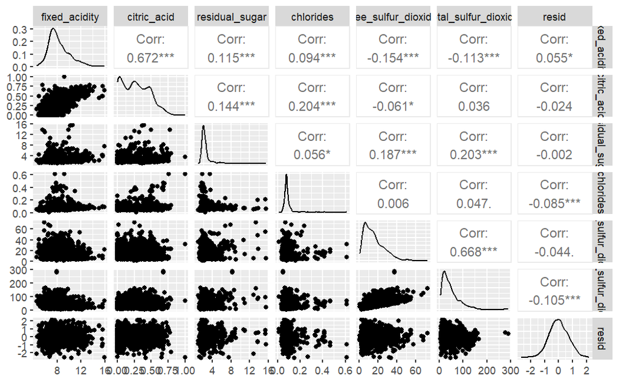

```r
red_wine_resids <- red_wine %>%
  add_residuals(mod_red3a) %>%
  select(-quality, -alcohol, -volatile_acidity, -sulphates)

ggpairs(red_wine_resids, columns = c(1:6, 12))
```

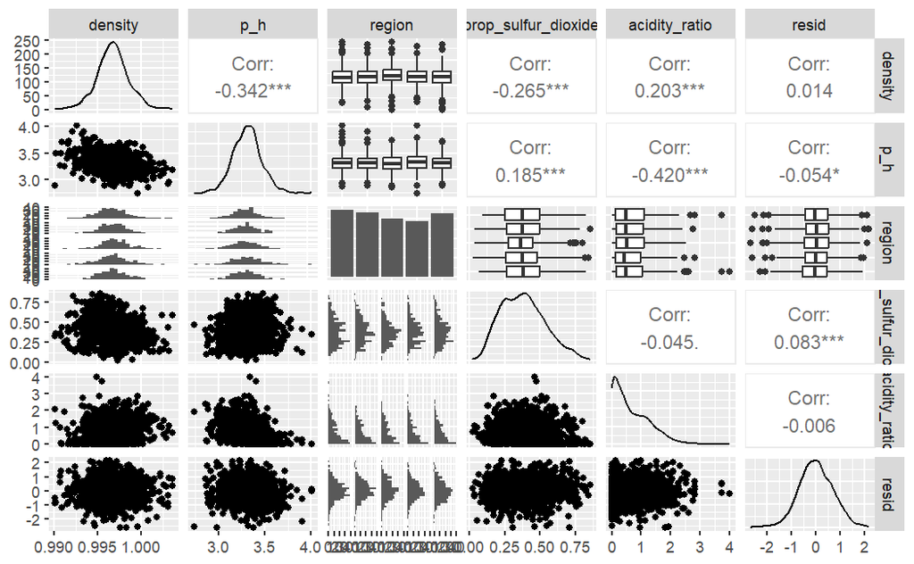

```r
ggpairs(red_wine_resids, columns = c(7:12))
```

None of the remaining predictors have particularly strong correlations, it seems unlikely that adding more are going to significantly improve the model

```r
mod_red4a <- lm(quality ~ alcohol + volatile_acidity + sulphates + prop_sulfur_dioxide, red_wine)
mod_red4b <- lm(quality ~ alcohol + volatile_acidity + sulphates + total_sulfur_dioxide, red_wine)

summary(mod_red3a)
```

```
Call:
lm(formula = quality ~ alcohol + volatile_acidity + sulphates,
    data = red_wine)

Residuals:
     Min       1Q   Median       3Q      Max
-2.66345 -0.45393 -0.01326  0.48807  2.16111

Coefficients:
                 Estimate Std. Error t value Pr(>|t|)
(Intercept)       2.62881    0.21133  12.439  < 2e-16 ***
alcohol           0.31134    0.01707  18.241  < 2e-16 ***
volatile_acidity -1.19442    0.10476 -11.401  < 2e-16 ***
sulphates         0.63716    0.10886   5.853 5.84e-09 ***
---
Signif. codes:  0 ‘***’ 0.001 ‘**’ 0.01 ‘*’ 0.05 ‘.’ 0.1 ‘ ’ 1

Residual standard error: 0.7114 on 1595 degrees of freedom
Multiple R-squared:  0.2985,    Adjusted R-squared:  0.2972
F-statistic: 226.2 on 3 and 1595 DF,  p-value: < 2.2e-16
```

```r
summary(mod_red4a)
```

```
Call:
lm(formula = quality ~ alcohol + volatile_acidity + sulphates +
    prop_sulfur_dioxide, data = red_wine)

Residuals:
    Min      1Q  Median      3Q     Max
-2.8052 -0.4546 -0.0015  0.4844  2.2120

Coefficients:
                    Estimate Std. Error t value Pr(>|t|)
(Intercept)          2.60649    0.21073  12.369  < 2e-16 ***
alcohol              0.29701    0.01752  16.955  < 2e-16 ***
volatile_acidity    -1.18236    0.10447 -11.317  < 2e-16 ***
sulphates            0.65279    0.10859   6.012 2.27e-09 ***
prop_sulfur_dioxide  0.40530    0.11836   3.424 0.000632 ***
---
Signif. codes:  0 ‘***’ 0.001 ‘**’ 0.01 ‘*’ 0.05 ‘.’ 0.1 ‘ ’ 1

Residual standard error: 0.709 on 1594 degrees of freedom
Multiple R-squared:  0.3036,    Adjusted R-squared:  0.3019
F-statistic: 173.8 on 4 and 1594 DF,  p-value: < 2.2e-16
```

```r
summary(mod_red4b)
```

```
Call:
lm(formula = quality ~ alcohol + volatile_acidity + sulphates +
    total_sulfur_dioxide, data = red_wine)

Residuals:
     Min       1Q   Median       3Q      Max
-2.67251 -0.45155  0.00669  0.47534  2.09986

Coefficients:
                       Estimate Std. Error t value Pr(>|t|)
(Intercept)           2.8573979  0.2167746  13.181  < 2e-16 ***
alcohol               0.2965481  0.0173182  17.124  < 2e-16 ***
volatile_acidity     -1.1701363  0.1043438 -11.214  < 2e-16 ***
sulphates             0.6723700  0.1085710   6.193 7.50e-10 ***
total_sulfur_dioxide -0.0023768  0.0005517  -4.308 1.75e-05 ***
---
Signif. codes:  0 ‘***’ 0.001 ‘**’ 0.01 ‘*’ 0.05 ‘.’ 0.1 ‘ ’ 1

Residual standard error: 0.7075 on 1594 degrees of freedom
Multiple R-squared:  0.3066,    Adjusted R-squared:  0.3048
F-statistic: 176.2 on 4 and 1594 DF,  p-value: < 2.2e-16
```

Adding total_sulphur_dioxide is the best improvement

```r
anova(mod_red3a, mod_red4b)
```

```
Analysis of Variance Table

Model 1: quality ~ alcohol + volatile_acidity + sulphates
Model 2: quality ~ alcohol + volatile_acidity + sulphates + total_sulfur_dioxide
  Res.Df    RSS Df Sum of Sq     F    Pr(>F)
1   1595 807.20
2   1594 797.91  1    9.2905 18.56 1.747e-05 ***
---
Signif. codes:  0 ‘***’ 0.001 ‘**’ 0.01 ‘*’ 0.05 ‘.’ 0.1 ‘ ’ 1
```

```r
BIC(mod_red3a)
```

```
[1] 3481.634
```

```r
BIC(mod_red4b)
```

```
[1] 3470.5
```

Statistical improvement and no evidence of overfitting. Should have done k-fold here instead to check model.

# White model

- alcohol 0.422
- density -0.297
- chlorides -0.201

## Round 1

```r
mod_white1a <- lm(quality ~ alcohol, train)
mod_white1b <- lm(quality ~ density, train)
mod_white1c <- lm(quality ~ chlorides, train)

summary(mod_white1a)
```

```
Call:
lm(formula = quality ~ alcohol, data = train)

Residuals:
    Min      1Q  Median      3Q     Max
-3.5163 -0.5570 -0.0210  0.5403  3.2874

Coefficients:
            Estimate Std. Error t value Pr(>|t|)
(Intercept)  2.55271    0.11617   21.97   <2e-16 ***
alcohol      0.31826    0.01097   29.02   <2e-16 ***
---
Signif. codes:  0 ‘***’ 0.001 ‘**’ 0.01 ‘*’ 0.05 ‘.’ 0.1 ‘ ’ 1

Residual standard error: 0.8475 on 3917 degrees of freedom
Multiple R-squared:  0.1769,    Adjusted R-squared:  0.1767
F-statistic: 841.9 on 1 and 3917 DF,  p-value: < 2.2e-16
```

```r
summary(mod_white1b)
```

```
Call:
lm(formula = quality ~ density, data = train)

Residuals:
    Min      1Q  Median      3Q     Max
-3.3897 -0.5919  0.0066  0.5422  3.7936

Coefficients:
            Estimate Std. Error t value Pr(>|t|)
(Intercept)   95.973      4.691   20.46   <2e-16 ***
density      -90.614      4.719  -19.20   <2e-16 ***
---
Signif. codes:  0 ‘***’ 0.001 ‘**’ 0.01 ‘*’ 0.05 ‘.’ 0.1 ‘ ’ 1

Residual standard error: 0.893 on 3917 degrees of freedom
Multiple R-squared:  0.08603,   Adjusted R-squared:  0.08579
F-statistic: 368.7 on 1 and 3917 DF,  p-value: < 2.2e-16
```

```r
summary(mod_white1c)
```

```
Call:
lm(formula = quality ~ chlorides, data = train)

Residuals:
    Min      1Q  Median      3Q     Max
-3.2812 -0.5963  0.0117  0.5257  3.4240

Coefficients:
            Estimate Std. Error t value Pr(>|t|)
(Intercept)  6.28499    0.03371  186.46   <2e-16 ***
chlorides   -8.40666    0.66405  -12.66   <2e-16 ***
---
Signif. codes:  0 ‘***’ 0.001 ‘**’ 0.01 ‘*’ 0.05 ‘.’ 0.1 ‘ ’ 1

Residual standard error: 0.9156 on 3917 degrees of freedom
Multiple R-squared:  0.03931,   Adjusted R-squared:  0.03906
F-statistic: 160.3 on 1 and 3917 DF,  p-value: < 2.2e-16
```

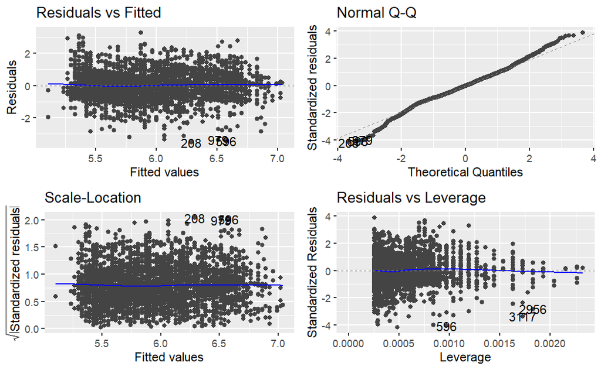

Diagnostics are great.

Alcohol seems to make the best model.

## Round 2

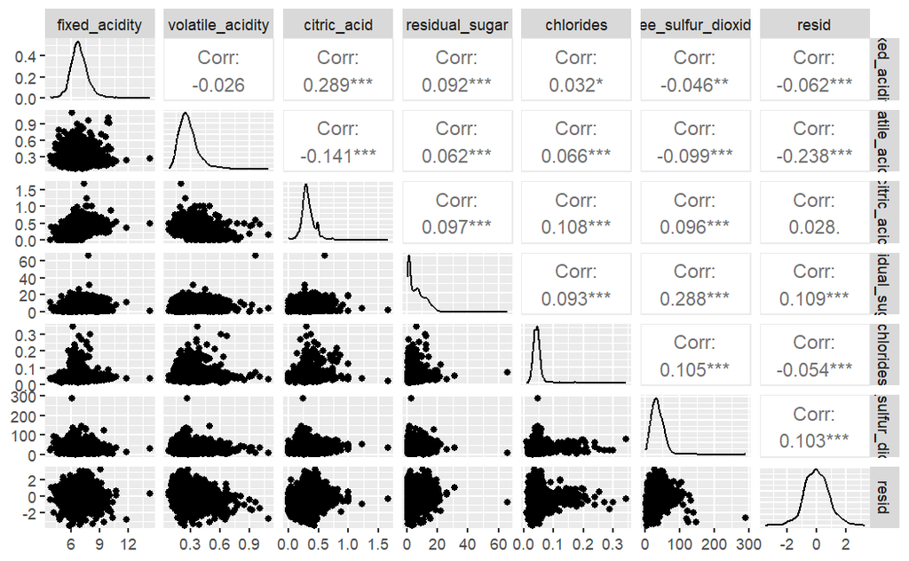

```r
train_resid <- train %>%
  add_residuals(mod_white1a) %>%
  select(-quality, -alcohol)

ggpairs(train_resid, columns = c(1:6, 14))
```

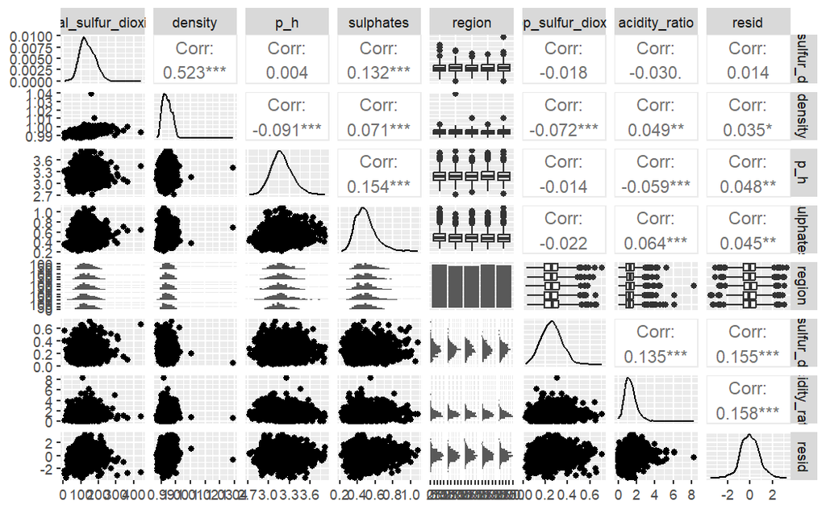

```r
ggpairs(train_resid, columns = c(7:14))
```

- volatile_acid
- acidity ratio
- prop sulfur

```r
mod_white2a <- lm(quality ~ alcohol + volatile_acidity, train)
mod_white2b <- lm(quality ~ alcohol + acidity_ratio, train)
mod_white2c <- lm(quality ~ alcohol + prop_sulfur_dioxide, train)

summary(mod_white2a)
```

```
Call:
lm(formula = quality ~ alcohol + volatile_acidity, data = train)

Residuals:
    Min      1Q  Median      3Q     Max
-3.5967 -0.5429 -0.0124  0.5240  3.2741

Coefficients:
                 Estimate Std. Error t value Pr(>|t|)
(Intercept)       2.98723    0.11739   25.45   <2e-16 ***
alcohol           0.32649    0.01071   30.47   <2e-16 ***
volatile_acidity -1.87678    0.13246  -14.17   <2e-16 ***
---
Signif. codes:  0 ‘***’ 0.001 ‘**’ 0.01 ‘*’ 0.05 ‘.’ 0.1 ‘ ’ 1

Residual standard error: 0.8267 on 3916 degrees of freedom
Multiple R-squared:  0.2171,    Adjusted R-squared:  0.2167
F-statistic: 542.8 on 2 and 3916 DF,  p-value: < 2.2e-16
```

```r
summary(mod_white2b)
```

```
Call:
lm(formula = quality ~ alcohol + acidity_ratio, data = train)

Residuals:
    Min      1Q  Median      3Q     Max
-3.6074 -0.5479 -0.0122  0.5374  3.2355

Coefficients:
              Estimate Std. Error t value Pr(>|t|)
(Intercept)    2.23141    0.12010  18.580   <2e-16 ***
alcohol        0.32554    0.01088  29.918   <2e-16 ***
acidity_ratio  0.17847    0.01933   9.231   <2e-16 ***
---
Signif. codes:  0 ‘***’ 0.001 ‘**’ 0.01 ‘*’ 0.05 ‘.’ 0.1 ‘ ’ 1

Residual standard error: 0.8385 on 3916 degrees of freedom
Multiple R-squared:  0.1944,    Adjusted R-squared:  0.194
F-statistic: 472.6 on 2 and 3916 DF,  p-value: < 2.2e-16
```

```r
summary(mod_white2c)
```

```
Call:
lm(formula = quality ~ alcohol + prop_sulfur_dioxide, data = train)

Residuals:
    Min      1Q  Median      3Q     Max
-3.6087 -0.5397 -0.0241  0.5225  3.3312

Coefficients:
                    Estimate Std. Error t value Pr(>|t|)
(Intercept)          2.25343    0.11786   19.12   <2e-16 ***
alcohol              0.30975    0.01084   28.57   <2e-16 ***
prop_sulfur_dioxide  1.52317    0.14189   10.73   <2e-16 ***
---
Signif. codes:  0 ‘***’ 0.001 ‘**’ 0.01 ‘*’ 0.05 ‘.’ 0.1 ‘ ’ 1

Residual standard error: 0.8354 on 3916 degrees of freedom
Multiple R-squared:  0.2004,    Adjusted R-squared:    0.2
F-statistic: 490.9 on 2 and 3916 DF,  p-value: < 2.2e-16
```

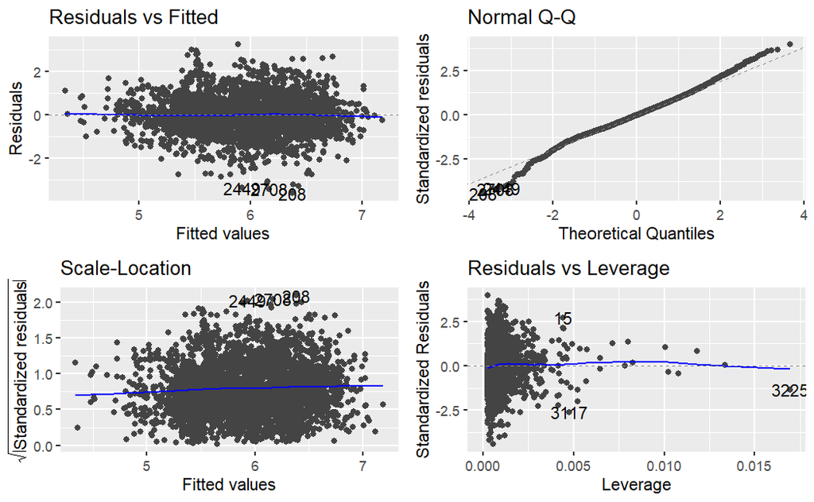

Volatile acidity is the next best predictor.

## Round 3

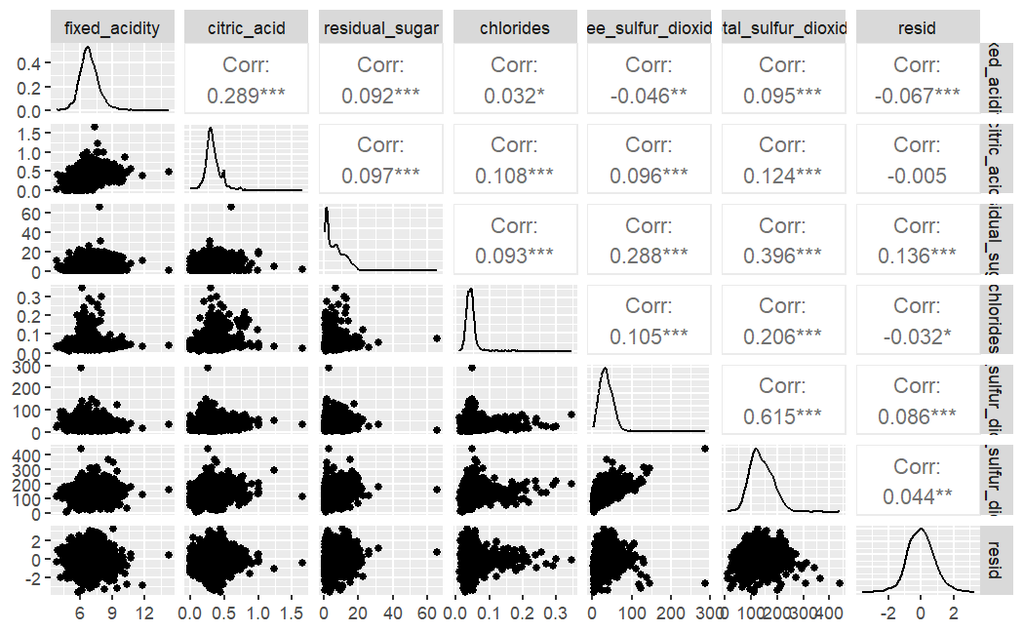

```r
train_resid <- train %>%
  add_residuals(mod_white2a) %>%
  select(-quality, -alcohol, -volatile_acidity)

ggpairs(train_resid, columns = c(1:6, 13))
```

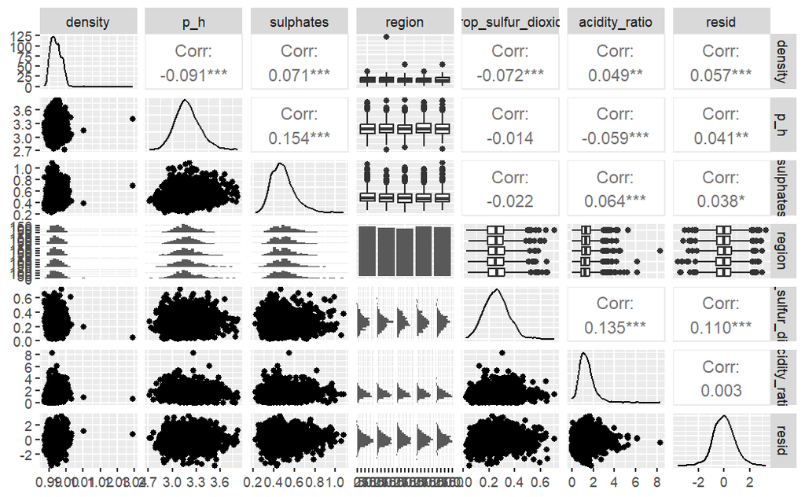

```r
ggpairs(train_resid, columns = c(7:13))
```

- residual sugar
- prop_sulfur_dioxide

```r
mod_white3a <- lm(quality ~ alcohol + volatile_acidity + residual_sugar, train)
mod_white3b <- lm(quality ~ alcohol + volatile_acidity + prop_sulfur_dioxide, train)

summary(mod_white3a)
```

```
Call:
lm(formula = quality ~ alcohol + volatile_acidity + residual_sugar,
    data = train)

Residuals:
    Min      1Q  Median      3Q     Max
-3.5848 -0.5370 -0.0097  0.5138  3.1942

Coefficients:
                 Estimate Std. Error t value Pr(>|t|)
(Intercept)       2.33589    0.13625  17.144   <2e-16 ***
alcohol           0.37597    0.01190  31.586   <2e-16 ***
volatile_acidity -2.00778    0.13186 -15.226   <2e-16 ***
residual_sugar    0.02626    0.00287   9.149   <2e-16 ***
---
Signif. codes:  0 ‘***’ 0.001 ‘**’ 0.01 ‘*’ 0.05 ‘.’ 0.1 ‘ ’ 1

Residual standard error: 0.8181 on 3915 degrees of freedom
Multiple R-squared:  0.2334,    Adjusted R-squared:  0.2329
F-statistic: 397.4 on 3 and 3915 DF,  p-value: < 2.2e-16
```

```r
summary(mod_white3b)
```

```
Call:
lm(formula = quality ~ alcohol + volatile_acidity + prop_sulfur_dioxide,
    data = train)

Residuals:
    Min      1Q  Median      3Q     Max
-3.5560 -0.5317 -0.0270  0.5109  3.3093

Coefficients:
                    Estimate Std. Error t value Pr(>|t|)
(Intercept)          2.70568    0.12130  22.306   <2e-16 ***
alcohol              0.31897    0.01066  29.914   <2e-16 ***
volatile_acidity    -1.65578    0.13404 -12.353   <2e-16 ***
prop_sulfur_dioxide  1.17251    0.14208   8.252   <2e-16 ***
---
Signif. codes:  0 ‘***’ 0.001 ‘**’ 0.01 ‘*’ 0.05 ‘.’ 0.1 ‘ ’ 1

Residual standard error: 0.8197 on 3915 degrees of freedom
Multiple R-squared:  0.2304,    Adjusted R-squared:  0.2299
F-statistic: 390.8 on 3 and 3915 DF,  p-value: < 2.2e-16
```

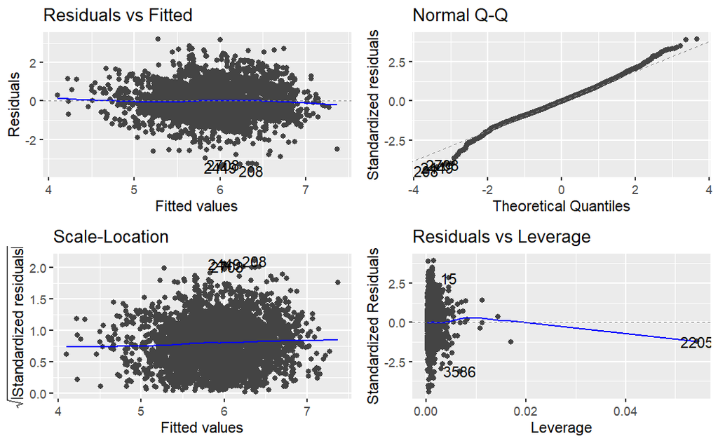

```r
autoplot(mod_white3a)
```

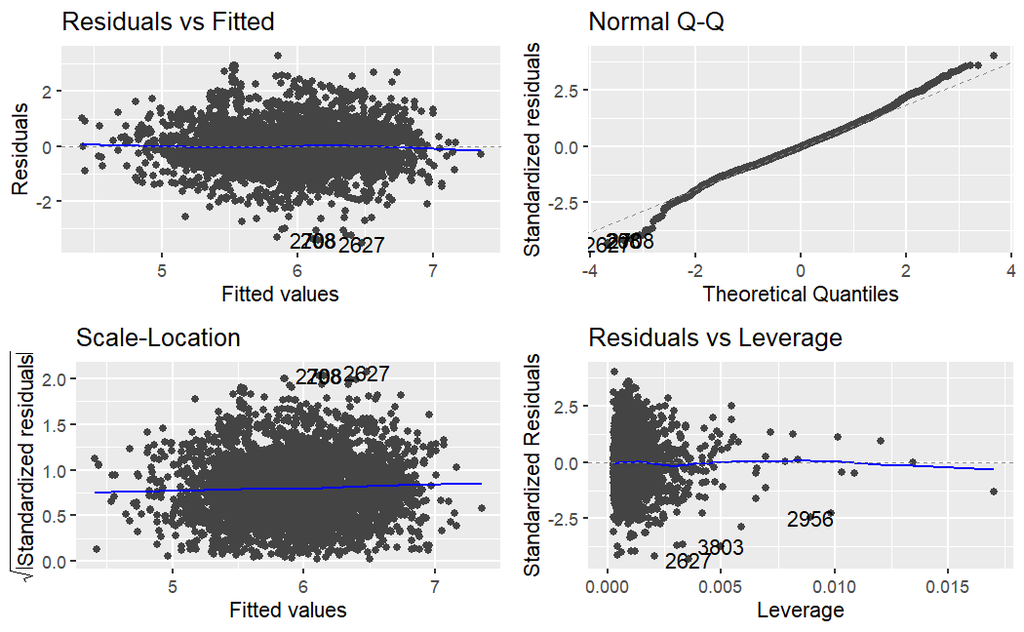

```r
autoplot(mod_white3b)
```

residual_sugar improves the r-squared the most and has the best correlation.

## Round 4

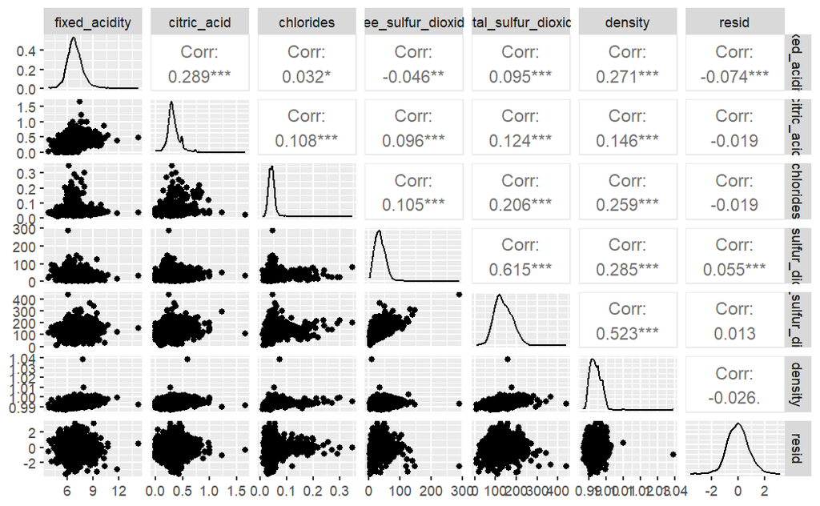

```r
train_resid <- train %>%
  add_residuals(mod_white3a) %>%
  select(-quality, -volatile_acidity, -residual_sugar, -alcohol)

ggpairs(train_resid, columns = c(1:6, 12))
```

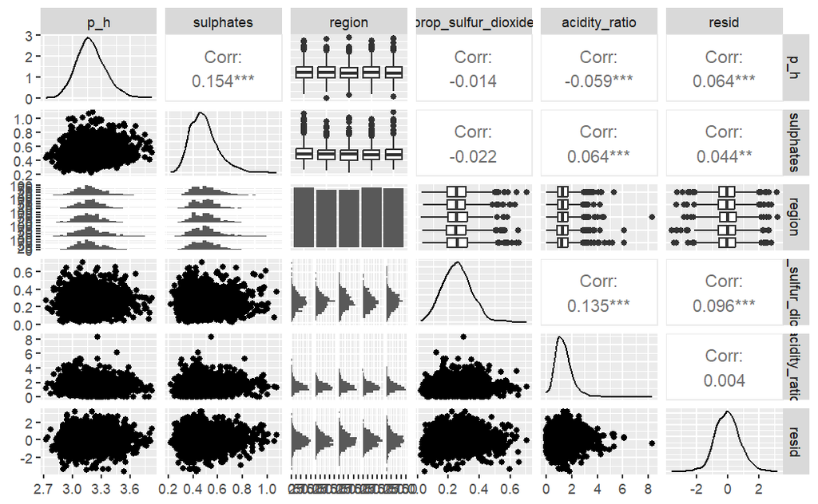

```r
ggpairs(train_resid, columns = c(7:12))
```

```r
mod_white4a <- lm(quality ~ alcohol + volatile_acidity + residual_sugar + prop_sulfur_dioxide, train)
mod_white4b <- lm(quality ~ alcohol + volatile_acidity + residual_sugar + fixed_acidity, train)

summary(mod_white4a)
```

```
Call:
lm(formula = quality ~ alcohol + volatile_acidity + residual_sugar +
    prop_sulfur_dioxide, data = train)

Residuals:
    Min      1Q  Median      3Q     Max
-3.5876 -0.5297 -0.0219  0.5189  3.2088

Coefficients:
                    Estimate Std. Error t value Pr(>|t|)
(Intercept)          2.14766    0.13778  15.587  < 2e-16 ***
alcohol              0.36474    0.01192  30.589  < 2e-16 ***
volatile_acidity    -1.80041    0.13403 -13.433  < 2e-16 ***
residual_sugar       0.02382    0.00287   8.299  < 2e-16 ***
prop_sulfur_dioxide  1.03566    0.14183   7.302 3.41e-13 ***
---
Signif. codes:  0 ‘***’ 0.001 ‘**’ 0.01 ‘*’ 0.05 ‘.’ 0.1 ‘ ’ 1

Residual standard error: 0.8127 on 3914 degrees of freedom
Multiple R-squared:  0.2437,    Adjusted R-squared:  0.243
F-statistic: 315.4 on 4 and 3914 DF,  p-value: < 2.2e-16
```

```r
summary(mod_white4b)
```

```
Call:
lm(formula = quality ~ alcohol + volatile_acidity + residual_sugar +
    fixed_acidity, data = train)

Residuals:
    Min      1Q  Median      3Q     Max
-3.6608 -0.5390 -0.0182  0.5053  3.3416

Coefficients:
                  Estimate Std. Error t value Pr(>|t|)
(Intercept)       2.939337   0.180189  16.312  < 2e-16 ***
alcohol           0.370285   0.011918  31.071  < 2e-16 ***
volatile_acidity -2.028281   0.131507 -15.423  < 2e-16 ***
residual_sugar    0.026805   0.002863   9.363  < 2e-16 ***
fixed_acidity    -0.078949   0.015492  -5.096 3.63e-07 ***
---
Signif. codes:  0 ‘***’ 0.001 ‘**’ 0.01 ‘*’ 0.05 ‘.’ 0.1 ‘ ’ 1

Residual standard error: 0.8155 on 3914 degrees of freedom
Multiple R-squared:  0.2385,    Adjusted R-squared:  0.2377
F-statistic: 306.5 on 4 and 3914 DF,  p-value: < 2.2e-16
```

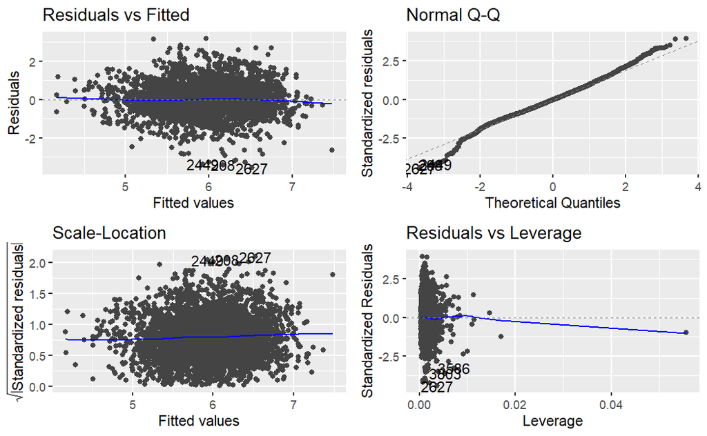

Looks good.

```r
anova(mod_white3a, mod_white4a)
```

[output not shown]

Is it worth adding any more?

## Round 5

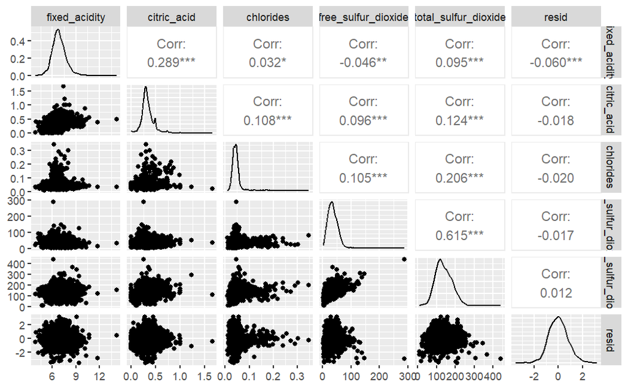

```r
train_resid <- train %>%
  add_residuals(mod_white4a) %>%
  select(-quality, -volatile_acidity, -residual_sugar, -alcohol, -prop_sulfur_dioxide)

ggpairs(train_resid, columns = c(1:5, 11))
```

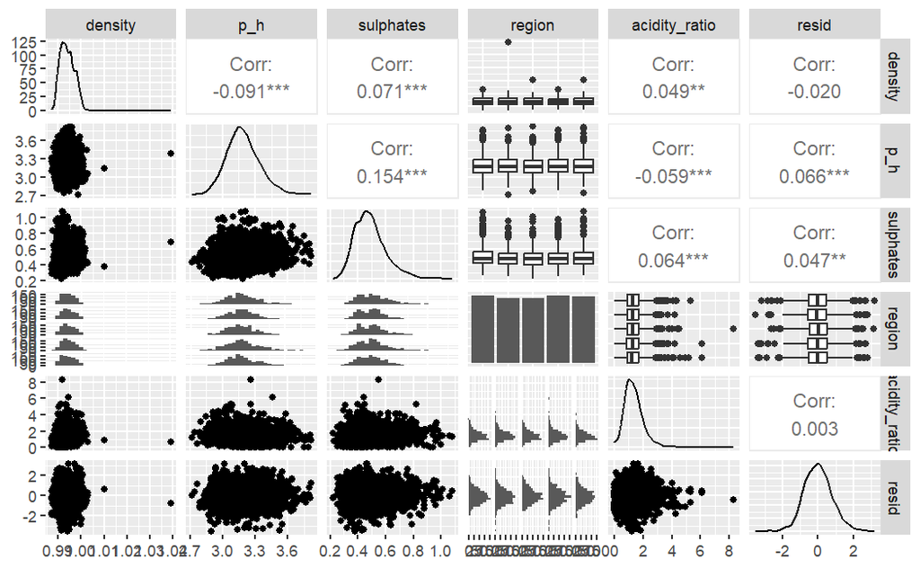

```r
ggpairs(train_resid, columns = c(6:11))
```

```r
mod_white5a <- lm(quality ~ alcohol + volatile_acidity +
                    residual_sugar + prop_sulfur_dioxide + fixed_acidity, train)
mod_white5b <- lm(quality ~ alcohol + volatile_acidity +
                    residual_sugar + prop_sulfur_dioxide + p_h, train)

summary(mod_white5a)
```

```
Call:
lm(formula = quality ~ alcohol + volatile_acidity + residual_sugar +
    prop_sulfur_dioxide + fixed_acidity, data = train)

Residuals:
    Min      1Q  Median      3Q     Max
-3.4343 -0.5308 -0.0231  0.5105  3.3482

Coefficients:
                     Estimate Std. Error t value Pr(>|t|)
(Intercept)          2.657515   0.184092  14.436  < 2e-16 ***
alcohol              0.360954   0.011934  30.247  < 2e-16 ***
volatile_acidity    -1.833488   0.133991 -13.684  < 2e-16 ***
residual_sugar       0.024461   0.002869   8.527  < 2e-16 ***
prop_sulfur_dioxide  0.954472   0.142870   6.681 2.71e-11 ***
fixed_acidity       -0.064774   0.015552  -4.165 3.18e-05 ***
---
Signif. codes:  0 ‘***’ 0.001 ‘**’ 0.01 ‘*’ 0.05 ‘.’ 0.1 ‘ ’ 1

Residual standard error: 0.811 on 3913 degrees of freedom
Multiple R-squared:  0.2471,    Adjusted R-squared:  0.2461
F-statistic: 256.8 on 5 and 3913 DF,  p-value: < 2.2e-16
```

```r
summary(mod_white5b)
```

```
Call:
lm(formula = quality ~ alcohol + volatile_acidity + residual_sugar +
    prop_sulfur_dioxide + p_h, data = train)

Residuals:
    Min      1Q  Median      3Q     Max
-3.4927 -0.5308 -0.0240  0.5123  3.2023

Coefficients:
                     Estimate Std. Error t value Pr(>|t|)
(Intercept)          0.762864   0.307160   2.484    0.013 *
alcohol              0.361891   0.011900  30.410  < 2e-16 ***
volatile_acidity    -1.787713   0.133642 -13.377  < 2e-16 ***
residual_sugar       0.026018   0.002895   8.989  < 2e-16 ***
prop_sulfur_dioxide  1.040278   0.141392   7.357 2.27e-13 ***
p_h                  0.437945   0.086886   5.040 4.85e-07 ***
---
Signif. codes:  0 ‘***’ 0.001 ‘**’ 0.01 ‘*’ 0.05 ‘.’ 0.1 ‘ ’ 1

Residual standard error: 0.8101 on 3913 degrees of freedom
Multiple R-squared:  0.2486,    Adjusted R-squared:  0.2477
F-statistic:   259 on 5 and 3913 DF,  p-value: < 2.2e-16
```

**Best so far - mod_white5b: lm(formula = quality ~ alcohol + volatile_acidity + residual_sugar + prop_sulfur_dioxide + p_h, data = train)**

```r
BIC(mod_white4a)
```

```
[1] 9540.294
```

```r
BIC(mod_white5b)
```

```
[1] 9523.205
```

Model 5 does not appear to be overfitting.

```r
anova(mod_white4a, mod_white5b)
```

```
Analysis of Variance Table

Model 1: quality ~ alcohol + volatile_acidity + residual_sugar + prop_sulfur_dioxide
Model 2: quality ~ alcohol + volatile_acidity + residual_sugar + prop_sulfur_dioxide +
    p_h
  Res.Df    RSS Df Sum of Sq      F    Pr(>F)
1   3914 2584.8
2   3913 2568.2  1    16.674 25.406 4.855e-07 ***
---
Signif. codes:  0 ‘***’ 0.001 ‘**’ 0.01 ‘*’ 0.05 ‘.’ 0.1 ‘ ’ 1
```

It is a significant improvement.

## Round 6

This is already a lot of variables, and perhaps one from each related field (eg. acidity/sulphur etc). It is important not to overfit the model.

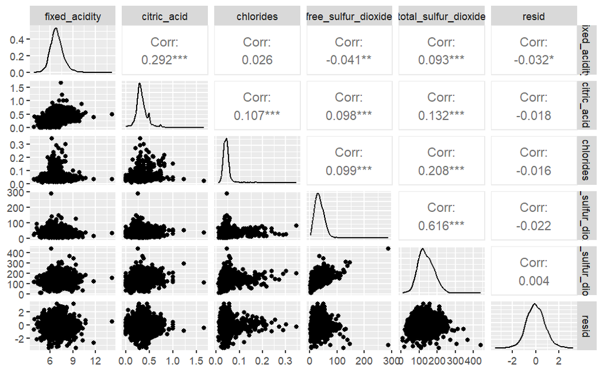

```r
train_resid <- train %>%
  add_residuals(mod_white5b) %>%
  select(-quality, -volatile_acidity, -residual_sugar, -alcohol, -prop_sulfur_dioxide, -p_h)

ggpairs(train_resid, columns = c(1:5, 10))
```

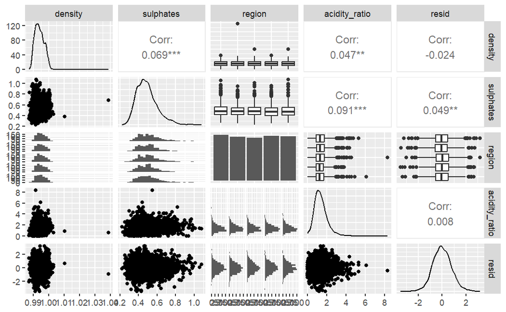

```r
ggpairs(train_resid, columns = c(6:10))
```

The correlation with the residuals are low. There are some interesting patterns in the plots such as fixed_acidity/chlorides and chlorides/total_sulfur_dioxide.

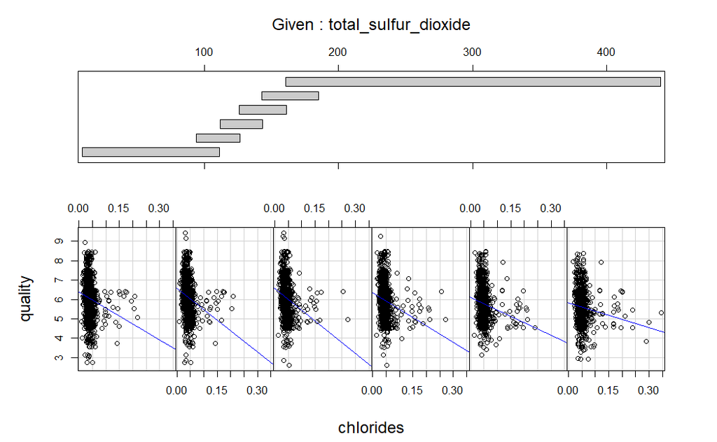

```r
coplot(quality ~ chlorides | total_sulfur_dioxide,
       data = train,
       rows = 1,
       panel = function(x, y, ...){
         points(x, y)
         abline(lm(y ~ x), col = "blue")
       })
```

The interactions are not clear.

## Test

Lets test the model

```r
predictions_test_5 <- test %>%
  add_predictions(mod_white5b) %>%
  select(quality, pred)
predictions_test_5
```

| quality | pred |
| --- | --- |
| 5.12 | 5.833128 |
| 6.36 | 6.394985 |
| 5.09 | 5.768664 |
| 7.51 | 6.492150 |
| 4.94 | 5.782174 |
| 6.56 | 6.275419 |
| 6.85 | 6.555156 |
| 6.38 | 5.948283 |
| 6.29 | 5.841492 |
| 8.48 | 5.559072 |

[output cut: 969 more lines]

```r
mse_test_5 <- predictions_test_5 %>%
  mutate(error = quality - pred) %>%
  summarise(mse = mean(error ** 2),
            rmse = mse ** 0.5)

mse_test_5
```

| mse | rmse |
| --- | --- |
| 0.6737614 | 0.8208297 |

```r
predictions_test_4 <- test %>%
  add_predictions(mod_white4a) %>%
  select(quality, pred)
predictions_test_4
```

| quality | pred |
| --- | --- |
| 5.12 | 5.788469 |
| 6.36 | 6.357608 |
| 5.09 | 5.719340 |
| 7.51 | 6.580668 |
| 4.94 | 5.811628 |
| 6.56 | 6.303373 |
| 6.85 | 6.567900 |
| 6.38 | 5.983886 |
| 6.29 | 5.773424 |
| 8.48 | 5.647064 |

[output cut: 969 more lines]

```r
mse_test_4 <- predictions_test_4 %>%
  mutate(error = quality - pred) %>%
  summarise(mse = mean(error ** 2),
            rmse = mse ** 0.5)
mse_test_4
```

| mse | rmse |
| --- | --- |
| 0.6732454 | 0.8205153 |

Model 4 actually does a slightly better job on the unseen data. Both are pretty good though.